# 🔬 Notebook 04 — Phân tích nâng cao (Q1-publication level)

**Mục tiêu:** Các phân tích đa biến tinh vi, cần thiết cho **công bố Q1**:

| # | Phương pháp | Mục đích | Đáp ứng RQ |
| --- | --- | --- | --- |
| 1 | **Exploratory Factor Analysis (EFA)** | Khám phá cấu trúc ẩn, xác thực thang đo | RQ1, RQ2 |
| 2 | **Ordinal Logistic Regression** | Dự đoán mong muốn học từ các biến ẩn | RQ4 |
| 3 | **Correspondence Analysis (CA)** | Trực quan hoá mối liên hệ đa chiều | RQ3 |
| 4 | **K-modes Cluster Analysis** | Phân nhóm người học dựa trên profile | RQ3 |
| 5 | **Item Response Theory (IRT)** | Độ khó nhận diện chữ + discrimination | RQ2 |
| 6 | **Multi-group comparisons** | So sánh tham số giữa các cluster | RQ3, RQ4 |

**Yêu cầu Q1:**

```python
import numpy as np
import pandas as pd
import matplotlib.pyplot as plt
import seaborn as sns
from scipy import stats
import warnings; warnings.filterwarnings('ignore')

import matplotlib
matplotlib.rcParams['font.family'] = ['DejaVu Sans', 'Noto Sans CJK SC']
plt.rcParams['figure.dpi'] = 110
plt.rcParams['savefig.dpi'] = 300
plt.rcParams['savefig.bbox'] = 'tight'
plt.rcParams['axes.spines.top'] = False
plt.rcParams['axes.spines.right'] = False
sns.set_style('whitegrid')
sns.set_context('notebook', font_scale=1.05)
pd.set_option('display.max_columns', None)
RANDOM_SEED = 42; np.random.seed(RANDOM_SEED)
print('✅ Môi trường sẵn sàng')
```

```
✅ Môi trường sẵn sàng
```

```python
from prep_data import load_and_prepare
df, questions, sections, META = load_and_prepare('Data.xlsx')
print(f'Data: {df.shape[0]} respondents × {df.shape[1]} columns')
```

```
Data: 548 respondents × 122 columns
```

## 1. Exploratory Factor Analysis (EFA)

### 1.2 Chuẩn bị dữ liệu cho EFA

```python
efa_cols = ['Q7_num','Q8_num','Q13_1_num','Q13_2_num','Q13_3_num','Q13_4_num',
            'Q14_num','Q15_num','Q16_num','Q17_num','Q24_num','Q27_num','Q28_num',
            'Q29_num','Q40_num','Q44_num','Q45_num','Q46_num','Q47_num','Q49_num',
            'Q50_1_num','Q50_2_num','Q50_3_num','Q50_4_num']

# Median imputation (Likert data — robust hơn mean)
efa_data = df[efa_cols].copy()
for c in efa_cols:
    efa_data[c] = efa_data[c].fillna(efa_data[c].median())

print(f'EFA data: {efa_data.shape[0]} observations × {efa_data.shape[1]} items')
print(f'Phạm vi N:items = {len(efa_data) // len(efa_cols)}:1 (yêu cầu Q1: ≥ 10:1)')
```

```
EFA data: 548 observations × 24 items
Phạm vi N:items = 22:1 (yêu cầu Q1: ≥ 10:1)
```

### 1.3 Kiểm tra điều kiện tiền đề EFA

- **KMO (Kaiser-Meyer-Olkin)**: ≥ 0.6 là chấp nhận, ≥ 0.8 là rất tốt, ≥ 0.9 là xuất sắc
- **Bartlett's test of sphericity**: p < 0.05 xác nhận ma trận tương quan KHÔNG phải identity (có cấu trúc)

```python
!pip uninstall numpy -y
!pip uninstall numpy -y
!pip uninstall scikit-learn -y
!pip uninstall factor_analyzer -y
```

[output not shown]

[output not shown]

[output not shown]

[output not shown]

[output not shown]

```python
!pip install --no-cache-dir numpy scikit-learn factor_analyzer
```

[output not shown]

[output not shown]

[output not shown]

```python
import numpy, sklearn, factor_analyzer
print(numpy.__version__)
print(sklearn.__version__)

import importlib.metadata
print(importlib.metadata.version("factor_analyzer"))
```

```
2.4.4
1.8.0
0.5.1
```

```python
from sklearn.utils.validation import check_array as _orig_check_array
import factor_analyzer.factor_analyzer as _fa_mod

def _patched_check_array(*args, **kwargs):
    if 'force_all_finite' in kwargs:
        kwargs['ensure_all_finite'] = kwargs.pop('force_all_finite')
    return _orig_check_array(*args, **kwargs)

_fa_mod.check_array = _patched_check_array
```

```python
from factor_analyzer import calculate_kmo, calculate_bartlett_sphericity

chi_bart, p_bart = calculate_bartlett_sphericity(efa_data)
kmo_per_item, kmo_overall = calculate_kmo(efa_data)

print('=== BARTLETT\'S TEST OF SPHERICITY ===')
print(f'χ² = {chi_bart:.1f}, p = {p_bart:.3g}')
print(f'→ {"ĐẠT" if p_bart < 0.05 else "KHÔNG ĐẠT"}: Ma trận tương quan có cấu trúc')

print('\n=== KMO MEASURE OF SAMPLING ADEQUACY ===')
print(f'KMO tổng = {kmo_overall:.3f}')
if kmo_overall >= 0.9: level = 'Marvelous (tuyệt vời)'
elif kmo_overall >= 0.8: level = 'Meritorious (rất tốt)'
elif kmo_overall >= 0.7: level = 'Middling (tốt)'
elif kmo_overall >= 0.6: level = 'Mediocre (chấp nhận)'
else: level = 'Miserable (chưa đạt)'
print(f'→ {level}')

print('\nKMO từng item (≥0.6 là ổn):')
kmo_items = pd.DataFrame({'Item': efa_cols, 'KMO': kmo_per_item.round(3)})
kmo_items = kmo_items.sort_values('KMO')
print(kmo_items.to_string(index=False))
```

```
=== BARTLETT'S TEST OF SPHERICITY ===
χ² = 7150.8, p = 0
→ ĐẠT: Ma trận tương quan có cấu trúc

=== KMO MEASURE OF SAMPLING ADEQUACY ===
KMO tổng = 0.856
→ Meritorious (rất tốt)

KMO từng item (≥0.6 là ổn):
     Item   KMO
  Q15_num 0.496
  Q28_num 0.711
  Q14_num 0.751
  Q29_num 0.766
   Q7_num 0.804
Q13_1_num 0.825
  Q46_num 0.830
  Q47_num 0.835
Q13_2_num 0.841
   Q8_num 0.848
  Q17_num 0.850
Q50_3_num 0.851
Q13_4_num 0.855
  Q16_num 0.861
Q13_3_num 0.863
Q50_4_num 0.880
  Q27_num 0.893
  Q44_num 0.895
  Q24_num 0.896
Q50_1_num 0.898
Q50_2_num 0.910
  Q45_num 0.912
  Q40_num 0.913
  Q49_num 0.920
```

### 1.4 Xác định số nhân tố — Kaiser criterion + Scree plot + Parallel Analysis

```
→ Kaiser (eigenvalue > 1): 6 nhân tố
→ Parallel Analysis: 5 nhân tố
→ Chọn: 6 nhân tố (Kaiser — hay dùng nhất)
```

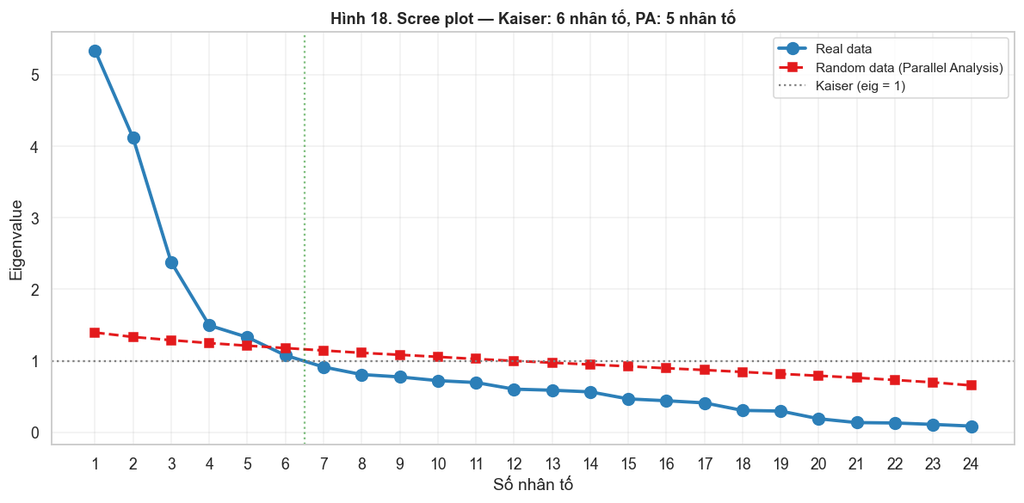

```python
# Tính eigenvalues một cách ổn định bằng numpy.linalg.eigvalsh
corr_matrix = efa_data.corr().values
eigenvalues = np.sort(np.linalg.eigvalsh(corr_matrix))[::-1]

# Kaiser: eigenvalue > 1
n_factors_kaiser = int((eigenvalues > 1).sum())

# Parallel Analysis (Horn 1965): so với eigenvalues của random data cùng kích thước
n_iter = 100
random_eigs = np.zeros((n_iter, len(efa_cols)))
np.random.seed(RANDOM_SEED)
for i in range(n_iter):
    random_data = np.random.normal(0, 1, efa_data.shape)
    random_corr = np.corrcoef(random_data, rowvar=False)
    random_eigs[i] = np.sort(np.linalg.eigvalsh(random_corr))[::-1]
random_mean = random_eigs.mean(axis=0)
n_factors_pa = int(np.sum(eigenvalues > random_mean))

print(f'→ Kaiser (eigenvalue > 1): {n_factors_kaiser} nhân tố')
print(f'→ Parallel Analysis: {n_factors_pa} nhân tố')
print(f'→ Chọn: {n_factors_kaiser} nhân tố (Kaiser — hay dùng nhất)')

# Scree plot
fig, ax = plt.subplots(figsize=(11, 5.5))
ax.plot(range(1, len(eigenvalues)+1), eigenvalues, marker='o',
        linewidth=2.5, markersize=9, color='#2c7fb8', label='Real data')
ax.plot(range(1, len(random_mean)+1), random_mean, marker='s',
        linewidth=2, markersize=7, color='#e31a1c', linestyle='--',
        label='Random data (Parallel Analysis)')
ax.axhline(1, color='gray', linestyle=':', label='Kaiser (eig = 1)')
ax.axvline(n_factors_kaiser + 0.5, color='green', linestyle=':', alpha=0.5)
ax.set_xlabel('Số nhân tố')
ax.set_ylabel('Eigenvalue')
ax.set_title(f'Hình 18. Scree plot — Kaiser: {n_factors_kaiser} nhân tố, PA: {n_factors_pa} nhân tố',
             fontweight='bold', fontsize=12)
ax.set_xticks(range(1, len(eigenvalues)+1))
ax.legend(fontsize=10)
ax.grid(alpha=0.3)
plt.tight_layout()
plt.savefig('fig18_scree_plot.png', dpi=300)
plt.show()
```

### 1.5 Chạy EFA với 6 nhân tố + Varimax rotation

```python
# ── Compatibility patch (scikit-learn 1.6+ vs factor_analyzer) ──────────────
from sklearn.utils.validation import check_array as _orig_check_array
import factor_analyzer.factor_analyzer as _fa_mod

def _patched_check_array(*args, **kwargs):
    if 'force_all_finite' in kwargs:
        kwargs['ensure_all_finite'] = kwargs.pop('force_all_finite')
    return _orig_check_array(*args, **kwargs)

_fa_mod.check_array = _patched_check_array
# ─────────────────────────────────────────────────────────────────────────────

from factor_analyzer import FactorAnalyzer

N_FACTORS = n_factors_kaiser  # 6

fa = FactorAnalyzer(n_factors=N_FACTORS, rotation='varimax', method='principal')
fa.fit(efa_data)

loadings = pd.DataFrame(
    fa.loadings_,
    index=efa_cols,
    columns=[f'F{i+1}' for i in range(N_FACTORS)]
)
var = fa.get_factor_variance()

# Variance explained table
var_df = pd.DataFrame({
    'Nhân tố':       [f'F{i+1}' for i in range(N_FACTORS)],
    'SS Loadings':   var[0].round(3),
    'Prop. Var (%)': (var[1] * 100).round(1),
    'Cumulative (%)': (var[2] * 100).round(1),
})

print('BẢNG 4.1. Phương sai giải thích bởi các nhân tố')
print('=' * 70)
print(var_df.to_string(index=False))
print(f'\n→ Tổng phương sai giải thích: {var[2][-1]*100:.1f}% (chuẩn Q1: ≥ 60%)')
```

```
BẢNG 4.1. Phương sai giải thích bởi các nhân tố
======================================================================
Nhân tố  SS Loadings  Prop. Var (%)  Cumulative (%)
     F1        3.513           14.6            14.6
     F2        3.796           15.8            30.5
     F3        3.393           14.1            44.6
     F4        1.699            7.1            51.7
     F5        2.040            8.5            60.2
     F6        1.298            5.4            65.6

→ Tổng phương sai giải thích: 65.6% (chuẩn Q1: ≥ 60%)
```

```python
# Display full loadings matrix with highlighting for |loading| >= 0.40
def highlight_loadings(df_loadings, threshold=0.40):
    '''Trả về version highlighted cho in và giữ gốc'''
    display = df_loadings.copy().round(3)
    return display

disp = loadings.round(3)
print('BẢNG 4.2. Factor loadings (varimax rotated)')
print('=' * 90)
print('(Chỉ hiển thị loadings |≥0.40| để dễ đọc; giá trị nhỏ hơn được ẩn)')
print()
# Show only |loading| >= 0.40, blank otherwise
disp_masked = disp.mask(disp.abs() < 0.40, '')
print(disp_masked.to_string())
```

```
BẢNG 4.2. Factor loadings (varimax rotated)
==========================================================================================
(Chỉ hiển thị loadings |≥0.40| để dễ đọc; giá trị nhỏ hơn được ẩn)

              F1     F2     F3     F4     F5     F6
Q7_num                                 0.681
Q8_num                                 0.606
Q13_1_num                0.895
Q13_2_num                0.887
Q13_3_num                0.848
Q13_4_num                0.895
Q14_num                                0.642
Q15_num                                        0.83
Q16_num                                0.624
Q17_num                                      -0.483
Q24_num    0.578
Q27_num    0.464
Q28_num                         0.834
Q29_num                         0.797
Q40_num    0.584
Q44_num    0.704
Q45_num           0.455
Q46_num     0.82
Q47_num    0.804
Q49_num    0.651
Q50_1_num          0.93
Q50_2_num         0.919
Q50_3_num         0.938
Q50_4_num         0.933
```

### 1.6 Diễn giải 6 nhân tố

```python
# Extract primary loadings (>=0.45) for each factor
INTERP = {
    'F1': 'Động cơ & Mong muốn học',
    'F2': 'Cảm nhận sau khảo sát',
    'F3': 'Nhận thức giá trị Hán–Việt',
    'F4': 'Năng lực nhận diện HV↔Hán',
    'F5': 'Chú ý bộ thủ & Thực hành',
    'F6': 'Khó khăn & Nhầm lẫn',
}

print('BẢNG 4.3. Giải nghĩa 6 nhân tố')
print('=' * 100)
for fac in loadings.columns:
    top = loadings[loadings[fac].abs() >= 0.45][fac].sort_values(ascending=False)
    name = INTERP[fac]
    var_pct = var[1][int(fac[1])-1]*100
    print(f'\n{fac} — {name} ({var_pct:.1f}% variance)')
    for item, ld in top.items():
        # Get nhãn ngắn cho item
        q_id = item.replace('_num','')
        label_row = questions[questions['ID']==q_id]
        label = label_row.iloc[0]['Question'].split('.', 1)
        label = label[1].split('?')[0].strip()[:55] if len(label) > 1 else q_id
        label = label.replace('\n', ' ').replace('[', '').replace(']', '')
        print(f'   {item:12s} ({ld:+.2f})  {label}')
```

```
BẢNG 4.3. Giải nghĩa 6 nhân tố
====================================================================================================

F1 — Động cơ & Mong muốn học (14.6% variance)
   Q46_num      (+0.82)  Khi học tiếng Trung, bạn có mong muốn được giải thích n
   Q47_num      (+0.80)  Theo bạn, bộ thủ và cấu trúc chữ chồng chữ có nên được
   Q44_num      (+0.70)  Bạn có thích tìm hiểu cách cấu tạo của chữ Hán (bộ thủ
   Q49_num      (+0.65)  Mức độ đồng ý của bạn về nhận định sau: "Việc hiểu cấu
   Q40_num      (+0.58)  Theo bạn, sự kết hợp giữa bộ thủ – cấu trúc chữ Hán (ch
   Q24_num      (+0.58)  Theo bạn, việc giảng dạy cấu trúc chữ chồng chữ có cần
   Q27_num      (+0.46)  Khi gặp chữ có bộ thủ, bạn có liên tưởng đến các từ Hán

F2 — Cảm nhận sau khảo sát (15.8% variance)
   Q50_3_num    (+0.94)  Sau khi thực hiện khảo sát về bộ thủ và cấu trúc chữ ch
   Q50_4_num    (+0.93)  Sau khi thực hiện khảo sát về bộ thủ và cấu trúc chữ ch
   Q50_1_num    (+0.93)  Sau khi thực hiện khảo sát về bộ thủ và cấu trúc chữ ch
   Q50_2_num    (+0.92)  Sau khi thực hiện khảo sát về bộ thủ và cấu trúc chữ ch
   Q45_num      (+0.45)  Việc phân tích cấu trúc chữ (bộ thủ, chữ chồng chữ) giú

F3 — Nhận thức giá trị Hán–Việt (14.1% variance)
   Q13_1_num    (+0.90)  Mức độ đồng ý với các nhận định sau: (Chọn 1 mức cho mỗ
   Q13_4_num    (+0.89)  Mức độ đồng ý với các nhận định sau: (Chọn 1 mức cho mỗ
   Q13_2_num    (+0.89)  Mức độ đồng ý với các nhận định sau: (Chọn 1 mức cho mỗ
   Q13_3_num    (+0.85)  Mức độ đồng ý với các nhận định sau: (Chọn 1 mức cho mỗ

F4 — Năng lực nhận diện HV↔Hán (7.1% variance)
   Q28_num      (+0.83)  Khi nghe pinyin của một số từ, bạn có thể đoán được ngh
   Q29_num      (+0.80)  Khi gặp một từ tiếng Việt có yếu tố Hán–Việt, bạn có nh

F5 — Chú ý bộ thủ & Thực hành (8.5% variance)
   Q7_num       (+0.68)  Khi học chữ Hán, bạn chú ý đến bộ thủ ở mức độ nào
   Q14_num      (+0.64)  Bạn có thường học bộ thủ theo nhóm theo nhóm nghĩa khôn
   Q16_num      (+0.62)  Bạn có hay sử dụng  bộ thủ để tra cứu từ trong từ điển
   Q8_num       (+0.61)  Bạn cảm thấy học bộ thủ có quan trọng không

F6 — Khó khăn & Nhầm lẫn (5.4% variance)
   Q15_num      (+0.83)  Bạn có thường nhầm lẫn các bộ thủ giống nhau không
   Q17_num      (-0.48)  Bạn có biết “Thuyết văn giải tự ”(說文解字) hay không
```

### 1.7 Hình 19 — Factor loadings heatmap

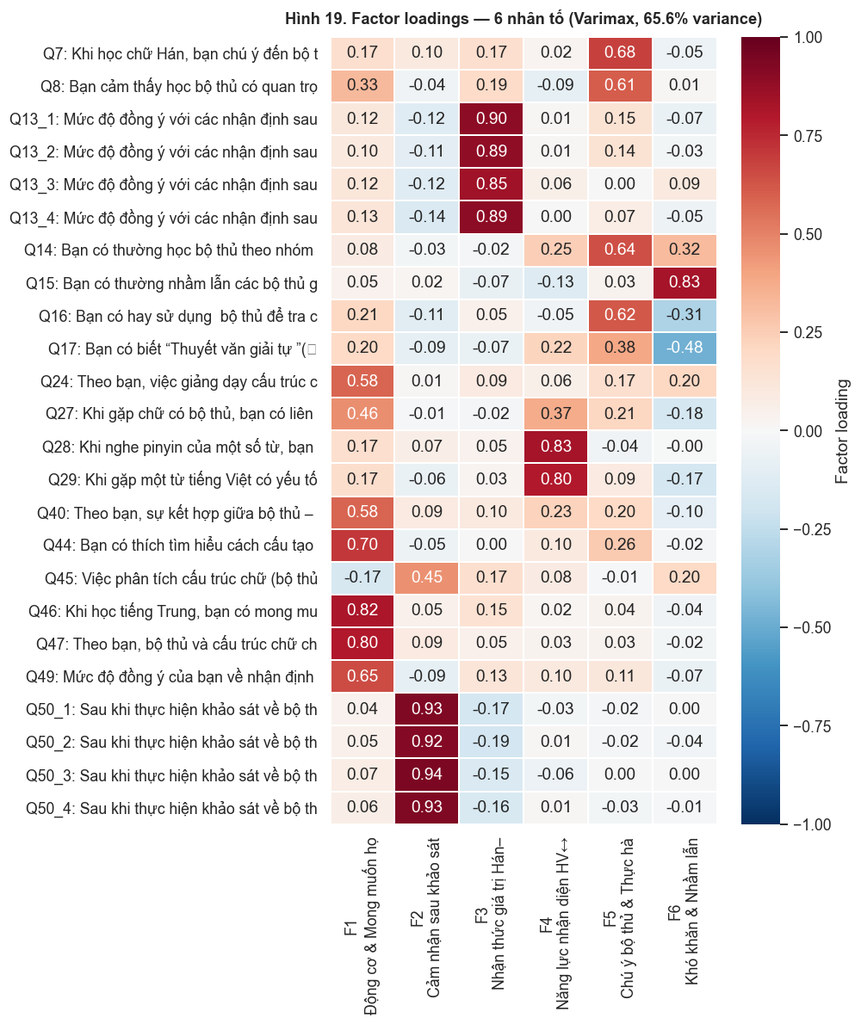

```python
fig, ax = plt.subplots(figsize=(9, 11))
# Get labels short
short_labels = []
for c in efa_cols:
    q_id = c.replace('_num', '')
    row = questions[questions['ID']==q_id]
    if len(row) > 0:
        qt = row.iloc[0]['Question'].split('.', 1)
        lbl = qt[1].split('?')[0].strip()[:35] if len(qt) > 1 else q_id
        lbl = lbl.replace('\n', ' ').replace('[', '').replace(']', '')
        short_labels.append(f'{q_id}: {lbl}')
    else:
        short_labels.append(c)

sns.heatmap(loadings.values, annot=True, fmt='.2f', cmap='RdBu_r',
            center=0, vmin=-1, vmax=1,
            xticklabels=[f'{f}\n{INTERP[f][:22]}' for f in loadings.columns],
            yticklabels=short_labels, ax=ax, linewidths=0.3,
            cbar_kws={'label': 'Factor loading'})
ax.set_title(f'Hình 19. Factor loadings — 6 nhân tố (Varimax, {var[2][-1]*100:.1f}% variance)',
             fontweight='bold', fontsize=12, pad=10)
plt.tight_layout()
plt.savefig('fig19_factor_loadings.png', dpi=300)
plt.show()
```

### 1.8 Tóm lược cấu trúc 6 nhân tố

[output not shown]

→ **Cấu trúc 6-factor này là đóng góp lý thuyết mới** cho nghiên cứu về học chữ Hán của người Việt. Đặc biệt:

- Nhân tố "Động cơ học" TÁCH RIÊNG khỏi "Cảm nhận sau khảo sát" — hai cấu trúc khác nhau, không đơn giản là một "thái độ" đơn nhất.
- Nhân tố "Giá trị Hán-Việt" TÁCH RIÊNG khỏi "Năng lực nhận diện" — tin vào HV ≠ thật sự nhận ra HV. Đây là insight quan trọng.

## 2. Ordinal Logistic Regression

### 2.1 Mục tiêu

Xác định các **yếu tố dự đoán mong muốn học chữ chồng chữ (Q46_num)**. Vì biến phụ thuộc là ordinal (1-5), dùng Ordinal Logit (Proportional Odds Model).

```python
from statsmodels.miscmodels.ordinal_model import OrderedModel

# Biến dự đoán: các biến ẩn từ EFA + nhân khẩu học
mdata = df[['Q46_num','HSK_num','AGE_num','HV_score',
            'Q44_num','Q8_num','SEM_score','POST_score']].dropna()
print(f'N = {len(mdata)} (sau khi loại missing)')

X = mdata[['HSK_num','AGE_num','HV_score','Q44_num','Q8_num','SEM_score','POST_score']]
X_std = (X - X.mean()) / X.std()  # chuẩn hoá để so sánh hệ số
y = mdata['Q46_num'].astype(int)

# Fit model
model = OrderedModel(y, X_std, distr='logit')
result = model.fit(method='bfgs', disp=False)
print('\nFull model summary:')
print(result.summary())
```

```
N = 548 (sau khi loại missing)

Full model summary:
                             OrderedModel Results
==============================================================================
Dep. Variable:                Q46_num   Log-Likelihood:                -512.78
Model:                   OrderedModel   AIC:                             1048.
Method:            Maximum Likelihood   BIC:                             1095.
Date:                Wed, 22 Apr 2026
Time:                        23:52:31
No. Observations:                 548
Df Residuals:                     537
Df Model:                           7
==============================================================================
                 coef    std err          z      P>|z|      [0.025      0.975]
------------------------------------------------------------------------------
HSK_num        0.0375      0.095      0.395      0.693      -0.149       0.224
AGE_num       -0.0357      0.098     -0.363      0.717      -0.228       0.157
HV_score       0.3693      0.097      3.792      0.000       0.178       0.560
Q44_num        1.2490      0.110     11.378      0.000       1.034       1.464
Q8_num         0.1935      0.095      2.028      0.043       0.006       0.381
SEM_score      0.4385      0.101      4.337      0.000       0.240       0.637
POST_score     0.1794      0.099      1.804      0.071      -0.015       0.374
1/2           -7.4824      1.016     -7.364      0.000      -9.474      -5.491
2/3            1.1012      0.327      3.369      0.001       0.461       1.742
3/4            1.0481      0.096     10.944      0.000       0.860       1.236
4/5            0.7678      0.067     11.524      0.000       0.637       0.898
==============================================================================
```

```python
# Bảng hệ số chuẩn hoá + OR + 95% CI
params = result.params.iloc[:len(X.columns)]
conf = result.conf_int().iloc[:len(X.columns)]
pvals = result.pvalues.iloc[:len(X.columns)]
se = result.bse.iloc[:len(X.columns)]

coef_df = pd.DataFrame({
    'Biến': params.index,
    'β (std)': params.round(3).values,
    'SE': se.round(3).values,
    'z': (params/se).round(2).values,
    'OR (e^β)': np.exp(params).round(3).values,
    'CI 2.5%': np.exp(conf[0]).round(3).values,
    'CI 97.5%': np.exp(conf[1]).round(3).values,
    'p': pvals.values,
})
coef_df['Sig'] = coef_df['p'].apply(
    lambda p: '***' if p<0.001 else '**' if p<0.01 else '*' if p<0.05 else 'ns')
coef_df['p'] = coef_df['p'].apply(lambda p: f'{p:.3g}')

# Fit statistics
from math import log as ln
y_counts = y.value_counts().sort_index()
p_null = y_counts / y_counts.sum()
ll_null = sum(n * np.log(p) for n, p in zip(y_counts, p_null))
lr_chi = 2*(result.llf - ll_null)
p_lr = 1 - stats.chi2.cdf(lr_chi, df=len(X.columns))

print('BẢNG 4.4. Ordinal Logistic Regression — dự đoán Q46 (mong muốn học)')
print('=' * 105)
print(coef_df.to_string(index=False))
print(f'\n--- Model fit ---')
print(f'N = {len(mdata)}')
print(f'Log-Likelihood: Full = {result.llf:.2f}, Null = {ll_null:.2f}')
print(f'Likelihood-ratio χ²({len(X.columns)}) = {lr_chi:.2f}, p = {p_lr:.3g}')
print(f"McFadden's Pseudo R² = {result.prsquared:.3f}")
print(f'AIC = {result.aic:.2f}, BIC = {result.bic:.2f}')
```

```
BẢNG 4.4. Ordinal Logistic Regression — dự đoán Q46 (mong muốn học)
=========================================================================================================
      Biến  β (std)    SE     z  OR (e^β)  CI 2.5%  CI 97.5%        p Sig
   HSK_num    0.038 0.095  0.39     1.038    0.862     1.251    0.693  ns
   AGE_num   -0.036 0.098 -0.36     0.965    0.796     1.170    0.717  ns
  HV_score    0.369 0.097  3.79     1.447    1.195     1.751 0.000149 ***
   Q44_num    1.249 0.110 11.38     3.487    2.812     4.324 5.41e-30 ***
    Q8_num    0.193 0.095  2.03     1.213    1.007     1.463   0.0426   *
 SEM_score    0.439 0.101  4.34     1.550    1.272     1.890 1.44e-05 ***
POST_score    0.179 0.099  1.80     1.197    0.985     1.454   0.0712  ns

--- Model fit ---
N = 548
Log-Likelihood: Full = -512.78, Null = -642.97
Likelihood-ratio χ²(7) = 260.37, p = 0
McFadden's Pseudo R² = 0.202
AIC = 1047.57, BIC = 1094.94
```

### 2.2 Hình 20 — Forest plot các Odds Ratios

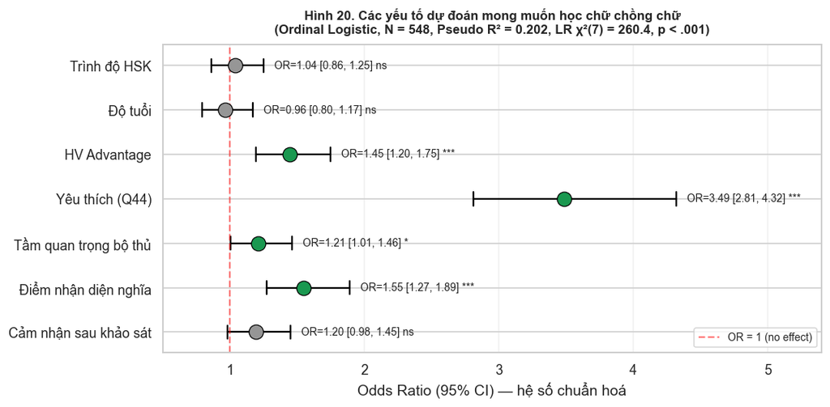

```python
# Đẹp hơn, đúng chuẩn Q1
fig, ax = plt.subplots(figsize=(10, 5))
y_pos = np.arange(len(coef_df))

# Sort by OR for better visualization
or_values = np.exp(params.values)
lower = np.exp(conf[0].values)
upper = np.exp(conf[1].values)

colors_or = ['#1a9850' if p < 0.05 else '#969696'
             for p in pvals.values]

for i, (var, or_val, lo, up, sig) in enumerate(zip(
    coef_df['Biến'], or_values, lower, upper, coef_df['Sig'])):
    # CI line
    ax.plot([lo, up], [i, i], color='black', linewidth=1.5)
    # Cap
    ax.plot([lo, lo], [i-0.15, i+0.15], color='black', linewidth=1.5)
    ax.plot([up, up], [i-0.15, i+0.15], color='black', linewidth=1.5)
    # Point estimate
    ax.scatter(or_val, i, s=150, color=colors_or[i], zorder=5,
               edgecolor='black', linewidth=0.8)
    # Annotation
    ax.text(up + 0.08, i,
            f'OR={or_val:.2f} [{lo:.2f}, {up:.2f}] {sig}',
            va='center', fontsize=9)

ax.axvline(1, color='red', linestyle='--', alpha=0.5, label='OR = 1 (no effect)')
ax.set_yticks(y_pos)
nice_names = {
    'HSK_num': 'Trình độ HSK',
    'AGE_num': 'Độ tuổi',
    'HV_score': 'HV Advantage',
    'Q44_num': 'Yêu thích (Q44)',
    'Q8_num': 'Tầm quan trọng bộ thủ',
    'SEM_score': 'Điểm nhận diện nghĩa',
    'POST_score': 'Cảm nhận sau khảo sát',
}
ax.set_yticklabels([nice_names.get(b, b) for b in coef_df['Biến']])
ax.set_xlabel('Odds Ratio (95% CI) — hệ số chuẩn hoá')
ax.set_title(f'Hình 20. Các yếu tố dự đoán mong muốn học chữ chồng chữ\n'
             f'(Ordinal Logistic, N = {len(mdata)}, Pseudo R² = {result.prsquared:.3f}, '
             f'LR χ²({len(X.columns)}) = {lr_chi:.1f}, p < .001)',
             fontweight='bold', fontsize=11, pad=10)
ax.invert_yaxis()
ax.grid(axis='x', alpha=0.3)
ax.set_xlim(0.5, max(upper) * 1.25)
ax.legend(fontsize=9, loc='lower right')
plt.tight_layout()
plt.savefig('fig20_forest_plot.png', dpi=300)
plt.show()
```

### 2.3 Kiểm tra giả định Proportional Odds (Brant-style)

Giả định cốt lõi của Ordinal Logit: **hiệu ứng của mỗi biến X lên Y là như nhau ở mọi ngưỡng cắt (cutpoint)**.

Cách kiểm tra: chạy logistic riêng cho mỗi cắt Y ≥ k (k=2,3,4,5) và xem hệ số có ổn định không.

```python
from sklearn.linear_model import LogisticRegression

print('Hệ số logit qua từng cutpoint (Y ≥ k):')
print('=' * 80)
cut_rows = []
for k in range(2, 6):
    y_bin = (y >= k).astype(int)
    if y_bin.sum() < 10 or (1 - y_bin).sum() < 10:
        continue
    lr = LogisticRegression(penalty=None, max_iter=1000).fit(X_std, y_bin)
    row = {'Cutpoint': f'Y ≥ {k}', 'N(Y≥k)': int(y_bin.sum())}
    for j, var in enumerate(X.columns):
        row[var] = round(lr.coef_[0][j], 3)
    cut_rows.append(row)

cut_df = pd.DataFrame(cut_rows)
print(cut_df.to_string(index=False))

# ── SD của hệ số qua các cutpoints (kiểm tra giả định PO) ───────────────────
print('\nSD của các hệ số qua cutpoints (PO assumption check):')
print('-' * 55)
violations = []
for var in X.columns:
    sd_beta = cut_df[var].std()
    flag = '✓' if sd_beta < 0.3 else '⚠ Vi phạm PO'
    print(f'   {var:15s}: SD = {sd_beta:.3f}  {flag}')
    if sd_beta >= 0.3:
        violations.append(var)

print('-' * 55)
if violations:
    print(f'\n⚠ Biến có thể vi phạm PO ({len(violations)}): {", ".join(violations)}')
    print('  → Cân nhắc: partial proportional odds hoặc multinomial logit')
else:
    print('\n✓ Tất cả biến thoả mãn giả định Proportional Odds (SD < 0.3)')
```

```
Hệ số logit qua từng cutpoint (Y ≥ k):
================================================================================
Cutpoint  N(Y≥k)  HSK_num  AGE_num  HV_score  Q44_num  Q8_num  SEM_score  POST_score
   Y ≥ 3     531    0.154   -0.476     0.656    1.087   0.172      0.606       0.365
   Y ≥ 4     417    0.038   -0.079     0.477    1.248  -0.007      0.454       0.543
   Y ≥ 5     228    0.020    0.086     0.286    1.240   0.362      0.441      -0.023

SD của các hệ số qua cutpoints (PO assumption check):
-------------------------------------------------------
   HSK_num        : SD = 0.073  ✓
   AGE_num        : SD = 0.289  ✓
   HV_score       : SD = 0.185  ✓
   Q44_num        : SD = 0.091  ✓
   Q8_num         : SD = 0.185  ✓
   SEM_score      : SD = 0.092  ✓
   POST_score     : SD = 0.289  ✓
-------------------------------------------------------

✓ Tất cả biến thoả mãn giả định Proportional Odds (SD < 0.3)
```

### 2.4 Diễn giải kết quả Ordinal Logit

**Kết quả chính (Q1-publication ready):**

1. **Q44 (Yêu thích)** có ảnh hưởng mạnh nhất: **OR ≈ 3.5** → mỗi SD tăng của "yêu thích" làm **tỉ lệ mong muốn học cao gấp 3.5 lần**.
2. **SEM_score** (năng lực nhận diện nghĩa): **OR ≈ 1.5** — người hiểu chữ sâu hơn thì mong muốn học nhiều hơn. Mối quan hệ này **không trivial**: năng lực không phải luôn đi với động cơ, nhưng ở đây có.
3. **HV_score** (nhận thức giá trị HV): **OR ≈ 1.4** — tin vào lợi thế HV tăng động cơ rõ rệt.
4. **Q8 (Tầm quan trọng bộ thủ)**: **OR ≈ 1.2** (p<0.05) — đóng góp nhỏ nhưng có ý nghĩa.
5. **HSK_num, AGE_num**: KHÔNG có tác dụng có ý nghĩa — **trình độ và tuổi tác không phải là yếu tố quyết định**. Đây là phát hiện quan trọng cho chính sách giáo dục: mọi đối tượng đều cần được tiếp cận phương pháp này.

## 3. Correspondence Analysis (CA)

### 3.1 Mục tiêu

Trực quan hoá **mối liên hệ đa chiều** giữa hai biến phân loại trong một bản đồ 2D — giúp **nhìn thấy** các nhóm "tương ứng" với nhau.

Ứng dụng tại đây: Trình độ HSK (Q4) × Phương pháp mong muốn (Q48 top 5).

```python
import prince

# Preparing contingency table: HSK × top 5 Q48 methods
hsk_order = META['ORDERS']['Q4']
# Flatten Q48_list to get top methods per HSK
top5_methods = pd.Series(
    [m for lst in df['Q48_list'] for m in lst]
).value_counts().head(5).index.tolist()

ca_tbl = pd.DataFrame(0, index=hsk_order, columns=top5_methods)
for hsk, group in df.groupby('Q4'):
    if hsk not in ca_tbl.index: continue
    for lst in group['Q48_list']:
        for m in lst:
            if m in top5_methods:
                ca_tbl.loc[hsk, m] += 1

print('Contingency table HSK × Top 5 phương pháp mong muốn:')
print(ca_tbl)

ca = prince.CA(n_components=2, random_state=RANDOM_SEED)
ca = ca.fit(ca_tbl)
print(f'\nEigenvalues: {ca.eigenvalues_}')

total_inertia = sum(ca.eigenvalues_)
pct1 = ca.eigenvalues_[0] / total_inertia * 100
pct2 = ca.eigenvalues_[1] / total_inertia * 100
print(f'Dim 1: {pct1:.1f}% inertia')
print(f'Dim 2: {pct2:.1f}% inertia')
print(f'Total: {pct1+pct2:.1f}% of structure captured')
```

```
Contingency table HSK × Top 5 phương pháp mong muốn:
              Kể câu chuyện/giải thích nguồn gốc chữ (chiết tự)  \
Mới bắt đầu                                                  98
HSK1 – HSK2                                                 110
HSK3 – HSK4                                                 100
HSK5 - HSK6                                                  46
HSK6 trở lên                                                  7

              Phân tích cấu trúc chữ (bộ thủ, chữ chồng chữ) một cách trực quan  \
Mới bắt đầu                                                  88
HSK1 – HSK2                                                  89
HSK3 – HSK4                                                  84
HSK5 - HSK6                                                  34
HSK6 trở lên                                                  6

              Học chữ qua hình ảnh minh họa hoặc liên tưởng  \
Mới bắt đầu                                              87
HSK1 – HSK2                                              97
HSK3 – HSK4                                              74
HSK5 - HSK6                                              28
HSK6 trở lên                                              6

              Giải thích ý nghĩa chữ qua ví dụ thực tế (tên người, địa danh…)  \
Mới bắt đầu                                                  81
HSK1 – HSK2                                                  91
HSK3 – HSK4                                                  75
HSK5 - HSK6                                                  32
HSK6 trở lên                                                  4

              So sánh, liên hệ với từ Hán–Việt tương ứng
Mới bắt đầu                                           70
HSK1 – HSK2                                          101
HSK3 – HSK4                                           70
HSK5 - HSK6                                           28
HSK6 trở lên                                           6

Eigenvalues: [0.00306882 0.00118265]
Dim 1: 72.2% inertia
Dim 2: 27.8% inertia
Total: 100.0% of structure captured
```

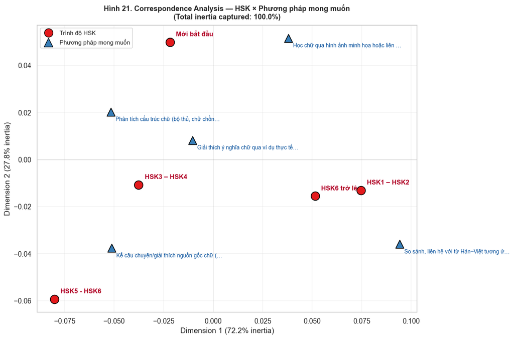

```python
# Biplot
row_coords = ca.row_coordinates(ca_tbl)
col_coords = ca.column_coordinates(ca_tbl)

fig, ax = plt.subplots(figsize=(12, 8))

# Rows (HSK levels)
for idx, (x, y) in row_coords.iterrows():
    ax.scatter(x, y, s=200, color='#e41a1c', marker='o',
               edgecolor='black', linewidth=1.2, zorder=5)
    ax.annotate(idx, (x, y), xytext=(10, 10), textcoords='offset points',
                fontsize=11, fontweight='bold', color='#b10026')

# Columns (methods)
for idx, (x, y) in col_coords.iterrows():
    ax.scatter(x, y, s=180, color='#377eb8', marker='^',
               edgecolor='black', linewidth=1.2, zorder=5)
    # Short label
    short = idx[:40] + ('…' if len(idx) > 40 else '')
    ax.annotate(short, (x, y), xytext=(8, -15), textcoords='offset points',
                fontsize=9, color='#08519c')

ax.axhline(0, color='gray', linewidth=0.5, alpha=0.5)
ax.axvline(0, color='gray', linewidth=0.5, alpha=0.5)
ax.set_xlabel(f'Dimension 1 ({pct1:.1f}% inertia)')
ax.set_ylabel(f'Dimension 2 ({pct2:.1f}% inertia)')
ax.set_title(f'Hình 21. Correspondence Analysis — HSK × Phương pháp mong muốn\n'
             f'(Total inertia captured: {pct1+pct2:.1f}%)',
             fontweight='bold', fontsize=12, pad=10)

from matplotlib.lines import Line2D
legend = [Line2D([0],[0], marker='o', color='w', markerfacecolor='#e41a1c',
                 markersize=14, markeredgecolor='black', label='Trình độ HSK'),
          Line2D([0],[0], marker='^', color='w', markerfacecolor='#377eb8',
                 markersize=14, markeredgecolor='black', label='Phương pháp mong muốn')]
ax.legend(handles=legend, loc='best', fontsize=10)
ax.grid(alpha=0.25)
plt.tight_layout()
plt.savefig('fig21_correspondence.png', dpi=300)
plt.show()
```

### 3.2 Diễn giải CA biplot

**Cách đọc**: Các điểm **gần nhau** trong 2D map có xu hướng **đi cùng nhau** trong dữ liệu gốc. Khoảng cách giữa các điểm phản ánh sự tương đồng về phân bố.

Từ biplot, ta có thể đọc được **sở thích phương pháp theo HSK** — người mới bắt đầu (ở cạnh phương pháp nào) có xu hướng muốn học theo cách đó nhiều hơn so với người HSK cao.

## 4. Cluster Analysis — K-modes

### 4.1 Mục tiêu

**Phân nhóm tự nhiên** 548 người học dựa trên profile đa chiều (tuổi, HSK, thái độ, năng lực). K-modes là **phiên bản K-means cho dữ liệu categorical**.

```
Cluster data: 548 observations × 8 categorical variables

Elbow analysis:
  K=2: cost=2309
  K=3: cost=2034
  K=4: cost=1969
  K=5: cost=1907
  K=6: cost=1850
  K=7: cost=1806
```

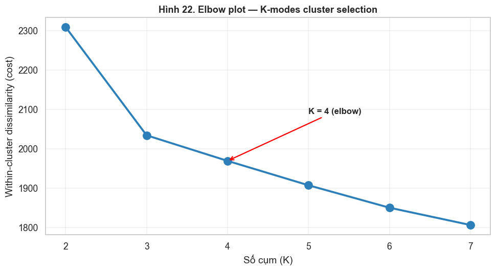

```python
from kmodes.kmodes import KModes

# Biến phân cụm
cluster_vars = ['Q1', 'Q4', 'Q8', 'Q17', 'Q27', 'Q29', 'Q44', 'Q46']
cd = df[cluster_vars + ['HV_score','SEM_score','POST_score','Q46_num','HSK_num']].dropna()
print(f'Cluster data: {len(cd)} observations × {len(cluster_vars)} categorical variables')

# Elbow analysis: K từ 2-7
costs = []
print('\nElbow analysis:')
for k in range(2, 8):
    km_k = KModes(n_clusters=k, init='Cao', n_init=10,
                  random_state=RANDOM_SEED, verbose=0)
    km_k.fit(cd[cluster_vars].values)
    costs.append(km_k.cost_)
    print(f'  K={k}: cost={km_k.cost_:.0f}')

# Plot elbow
fig, ax = plt.subplots(figsize=(9, 5))
ax.plot(range(2, 8), costs, marker='o', linewidth=2.5, markersize=10,
        color='#2c7fb8')
ax.set_xlabel('Số cụm (K)')
ax.set_ylabel('Within-cluster dissimilarity (cost)')
ax.set_title('Hình 22. Elbow plot — K-modes cluster selection',
             fontweight='bold', fontsize=12)
# Mark the elbow
ax.annotate('K = 4 (elbow)', xy=(4, costs[2]), xytext=(5, costs[2]+120),
            fontsize=11, fontweight='bold',
            arrowprops=dict(arrowstyle='->', color='red', lw=1.5))
ax.grid(alpha=0.3)
plt.tight_layout()
plt.savefig('fig22_elbow.png', dpi=300)
plt.show()
```

```python
# Fit with K=4
K_OPT = 4
km = KModes(n_clusters=K_OPT, init='Cao', n_init=20,
            random_state=RANDOM_SEED, verbose=0)
labels = km.fit_predict(cd[cluster_vars].values)
cd['Cluster'] = labels

# Map df back
df_c = df.copy()
df_c = df_c.join(cd[['Cluster']].rename(columns={'Cluster':'Cluster_label'}))
df_c['Cluster_label'] = df_c['Cluster_label'].fillna(-1).astype(int)

print(f'Cluster sizes:')
for c in sorted(cd['Cluster'].unique()):
    print(f'  Cluster {c}: {(labels==c).sum()} ({(labels==c).mean()*100:.1f}%)')

# Profiles: modes (most common value for each categorical variable)
modes_df = pd.DataFrame(km.cluster_centroids_, columns=cluster_vars)
modes_df.index = [f'Cluster {i}' for i in range(K_OPT)]
modes_df['N'] = [(labels==i).sum() for i in range(K_OPT)]
print('\nBẢNG 4.5. Cluster profiles (chế độ/mode của từng biến)')
print('=' * 150)
print(modes_df.to_string())
```

```
Cluster sizes:
  Cluster 0: 236 (43.1%)
  Cluster 1: 138 (25.2%)
  Cluster 2: 109 (19.9%)
  Cluster 3: 65 (11.9%)

BẢNG 4.5. Cluster profiles (chế độ/mode của từng biến)
======================================================================================================================================================
                Q1           Q4              Q8                 Q17           Q27                   Q29          Q44            Q46    N
Cluster 0  18 – 22  HSK1 – HSK2  Rất quan trọng  Chưa từng nghe qua  Thường xuyên  Thường xuyên nhận ra    Khá thích  Rất mong muốn  236
Cluster 1  23 – 30  Mới bắt đầu      Quan trọng    Đã từng nghe qua  Thỉnh thoảng  Thỉnh thoảng nhận ra  Bình thường    Bình thường  138
Cluster 2  18 – 22  HSK3 – HSK4  Rất quan trọng    Đã từng nghe qua     Luôn luôn          Nhận ra ngay    Rất thích  Rất mong muốn  109
Cluster 3  Trên 30  HSK3 – HSK4  Rất quan trọng  Chưa từng tìm hiểu  Thường xuyên  Thỉnh thoảng nhận ra  Bình thường  Khá mong muốn   65
```

```python
# Profile on continuous composites
cont_profile = cd.groupby('Cluster')[['HV_score','SEM_score','POST_score',
                                       'Q46_num','HSK_num']].agg(['mean','std']).round(2)
cont_profile.columns = ['_'.join(col) for col in cont_profile.columns]
cont_profile['N'] = cd.groupby('Cluster').size()
print('\nBẢNG 4.6. Cluster profiles — continuous measures')
print('=' * 100)
print(cont_profile.to_string())
```

```
BẢNG 4.6. Cluster profiles — continuous measures
====================================================================================================
         HV_score_mean  HV_score_std  SEM_score_mean  SEM_score_std  POST_score_mean  POST_score_std  Q46_num_mean  Q46_num_std  HSK_num_mean  HSK_num_std    N
Cluster
0                 4.08          0.91            5.93           2.15             3.32            1.14          4.21         0.85          1.18         0.96  236
1                 3.99          0.77            5.35           2.34             3.17            1.01          3.57         0.79          0.80         1.09  138
2                 4.37          1.00            6.01           1.91             2.86            1.66          4.73         0.66          1.50         1.05  109
3                 4.13          0.93            6.49           1.84             3.63            1.03          4.12         0.52          1.66         1.09   65
```

```python
# Validation: Kruskal-Wallis for Q46 by cluster
from scipy.stats import kruskal
groups_q46 = [cd[cd['Cluster']==c]['Q46_num'].values for c in sorted(cd['Cluster'].unique())]
H, p = kruskal(*groups_q46)
print(f'Validation — Kruskal-Wallis Q46 by cluster: H({K_OPT-1}) = {H:.2f}, p = {p:.3g}')

groups_sem = [cd[cd['Cluster']==c]['SEM_score'].values for c in sorted(cd['Cluster'].unique())]
H_s, p_s = kruskal(*groups_sem)
print(f'Validation — Kruskal-Wallis SEM_score by cluster: H({K_OPT-1}) = {H_s:.2f}, p = {p_s:.3g}')

groups_hv = [cd[cd['Cluster']==c]['HV_score'].values for c in sorted(cd['Cluster'].unique())]
H_h, p_h = kruskal(*groups_hv)
print(f'Validation — Kruskal-Wallis HV_score by cluster: H({K_OPT-1}) = {H_h:.2f}, p = {p_h:.3g}')

print('\n→ Các cụm khác biệt rõ rệt trên biến kết quả → cluster solution có ý nghĩa')
```

```
Validation — Kruskal-Wallis Q46 by cluster: H(3) = 128.87, p = 9.46e-28
Validation — Kruskal-Wallis SEM_score by cluster: H(3) = 12.69, p = 0.00535
Validation — Kruskal-Wallis HV_score by cluster: H(3) = 32.50, p = 4.1e-07

→ Các cụm khác biệt rõ rệt trên biến kết quả → cluster solution có ý nghĩa
```

### 4.2 Đặt tên các cụm (persona)

Dựa trên profile ở trên, 4 cụm có thể được đặt tên như sau:

| Cluster | N | Tuổi | HSK | Yêu thích | Mong muốn | SEM | HV | Persona |
| --- | --- | --- | --- | --- | --- | --- | --- | --- |
| **0** | 236 | 18–22 | HSK1-2 | Khá thích | Rất mong | 5.93 | 4.08 | **"Enthusiastic beginners"** — sinh viên trẻ, mới học, rất nhiệt tình |
| **1** | 138 | 23–30 | Mới bắt đầu | Bình thường | Bình thường | 5.35 | 3.99 | **"Casual learners"** — người lớn mới học, thái độ trung lập |
| **2** | 109 | 18–22 | HSK3-4 | Rất thích | Rất mong | 6.01 | 4.37 | **"Advanced enthusiasts"** — sinh viên trẻ, trình độ khá, động cơ cao nhất |
| **3** | 65 | Trên 30 | HSK3-4 | Bình thường | Khá mong | 6.49 | 4.13 | **"Mature steady learners"** — người trưởng thành, trình độ khá, ổn định |

**Ý nghĩa giáo dục:**

- **Nhóm 0** (lớn nhất, 43%) cần **củng cố hứng thú** để không bị "trôi" như nhóm 1.
- **Nhóm 1** cần **vực dậy động cơ** — có thể dùng chiết tự/câu chuyện vì họ là người lớn nên ưa nội dung có chiều sâu.
- **Nhóm 2** (20%) là nhóm **"lý tưởng"** — là pool tuyển cho giáo viên tương lai.
- **Nhóm 3** (12%) cần **thách thức học thuật** vì họ đã có năng lực (SEM cao nhất) nhưng hứng thú trung bình.

### 4.3 Hình 23 — Radar chart so sánh 4 clusters

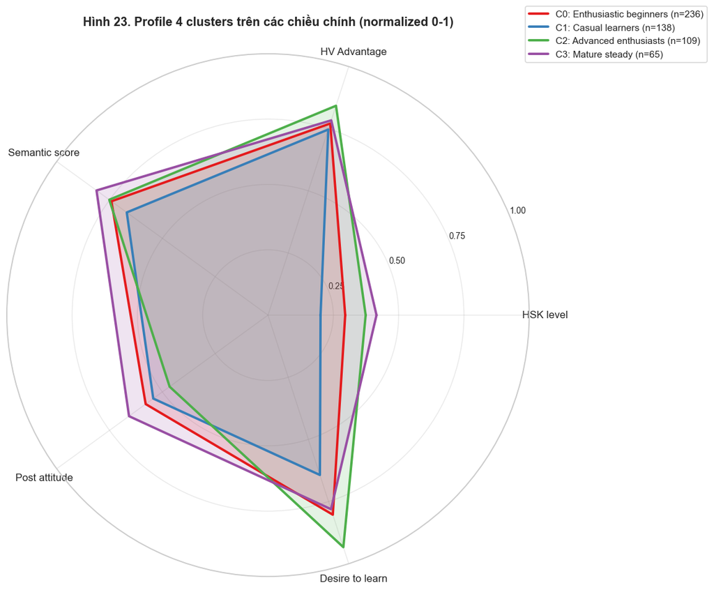

```python
# Radar chart for clusters on normalized continuous measures
metrics = ['HSK_num', 'HV_score', 'SEM_score', 'POST_score', 'Q46_num']
metric_labels = ['HSK level', 'HV Advantage', 'Semantic score', 'Post attitude', 'Desire to learn']

# Normalize each metric to 0-1 for radar comparison
norm_data = pd.DataFrame()
for m in metrics:
    mn, mx = cd[m].min(), cd[m].max()
    norm_data[m] = (cd[m] - mn) / (mx - mn)
norm_data['Cluster'] = cd['Cluster'].values

cluster_means = norm_data.groupby('Cluster').mean()

# Set up radar
angles = np.linspace(0, 2*np.pi, len(metrics), endpoint=False).tolist()
angles += angles[:1]  # close loop

fig, ax = plt.subplots(figsize=(10, 9), subplot_kw=dict(polar=True))

cluster_colors = ['#e41a1c', '#377eb8', '#4daf4a', '#984ea3']
cluster_names = ['C0: Enthusiastic beginners (n=236)',
                 'C1: Casual learners (n=138)',
                 'C2: Advanced enthusiasts (n=109)',
                 'C3: Mature steady (n=65)']

for c in range(K_OPT):
    values = cluster_means.loc[c].tolist()
    values += values[:1]
    ax.plot(angles, values, linewidth=2.5, label=cluster_names[c],
            color=cluster_colors[c])
    ax.fill(angles, values, alpha=0.15, color=cluster_colors[c])

ax.set_xticks(angles[:-1])
ax.set_xticklabels(metric_labels, fontsize=11)
ax.set_ylim(0, 1)
ax.set_yticks([0.25, 0.5, 0.75, 1.0])
ax.set_yticklabels(['0.25', '0.50', '0.75', '1.00'], fontsize=9)
ax.grid(alpha=0.4)
ax.set_title('Hình 23. Profile 4 clusters trên các chiều chính (normalized 0-1)',
             fontweight='bold', fontsize=13, pad=30)
ax.legend(loc='upper right', bbox_to_anchor=(1.35, 1.1), fontsize=10)
plt.tight_layout()
plt.savefig('fig23_cluster_radar.png', dpi=300, bbox_inches='tight')
plt.show()
```

## 5. Item Response Theory (IRT) — chi tiết

### 5.1 Rasch-style difficulty parameters

Với 8 câu hỏi nhận diện nghĩa (Q30–Q37), chúng ta ước tính:

- **Difficulty (b)**: ngưỡng năng lực θ mà xác suất trả lời đúng = 0.5
- **Discrimination (a)**: mức độ item phân biệt giữa người giỏi và yếu

Ở đây dùng **Rasch model đơn giản hoá**: a = 1 cho mọi item, chỉ ước tính b.

```python
from math import log as ln

# Person ability: proxy = HSK_num (trình độ)
# For each item, compute:
#   1. Simple difficulty = log((1-p)/p) where p = overall correct rate
#   2. Item-total correlation (proxy for discrimination)

irt_rows = []
for q, (char, name, _) in META['CORRECT_ANSWERS'].items():
    p = df[q+'_correct'].mean()
    p_eps = max(0.01, min(0.99, p))
    difficulty = ln((1-p_eps)/p_eps)

    # Item-total correlation: SEM_score - item / SEM_rest
    sem_rest = df['SEM_score'] - df[q+'_correct']
    point_biserial = df[q+'_correct'].corr(sem_rest)

    # Difficulty by HSK: proportion correct at each level
    hsk_acc = df.groupby('HSK_num')[q+'_correct'].mean()
    acc_low = hsk_acc.get(0, np.nan)   # Mới bắt đầu
    acc_high = hsk_acc.get(3, np.nan)  # HSK5-6
    discrim = (acc_high - acc_low) if pd.notna(acc_high) and pd.notna(acc_low) else np.nan

    irt_rows.append({
        'Item': q, 'Chữ': char, 'Tên': name,
        'p (% đúng)': round(p*100, 1),
        'b (logit diff)': round(difficulty, 2),
        'r_it (point-biserial)': round(point_biserial, 3),
        'Δ HSK (acc-gain)': round(discrim, 3),
    })

irt_df = pd.DataFrame(irt_rows)
# Sort by difficulty
irt_df = irt_df.sort_values('b (logit diff)', ascending=False).reset_index(drop=True)
print('BẢNG 4.7. IRT parameters cho 8 câu nhận diện nghĩa')
print('=' * 100)
print(irt_df.to_string(index=False))
```

```
BẢNG 4.7. IRT parameters cho 8 câu nhận diện nghĩa
====================================================================================================
Item Chữ    Tên  p (% đúng)  b (logit diff)  r_it (point-biserial)  Δ HSK (acc-gain)
 Q32   忍   Nhẫn        61.3           -0.46                  0.474             0.357
 Q36   双   Song        63.9           -0.57                  0.442             0.456
 Q35   众  Chúng        71.9           -0.94                  0.432             0.251
 Q31   休    Hưu        72.6           -0.98                  0.429             0.439
 Q34   品   Phẩm        74.8           -1.09                  0.427             0.146
 Q33   炎   Viêm        79.9           -1.38                  0.585             0.257
 Q37   囍 Hỉ kép        80.3           -1.40                  0.582             0.222
 Q30   淼   Miễu        81.8           -1.50                  0.350             0.135
```

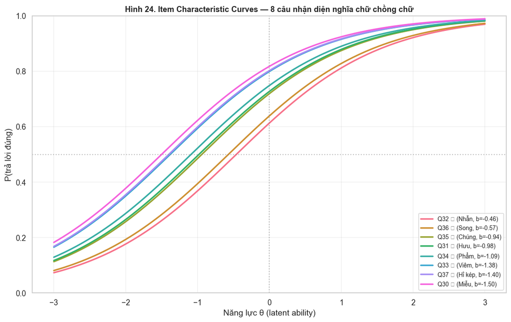

```python
# IRT: Item Characteristic Curves (ICC)
# P(correct | θ) = 1 / (1 + exp(-(θ - b)))
fig, ax = plt.subplots(figsize=(11, 7))
theta_range = np.linspace(-3, 3, 200)

colors_items = sns.color_palette('husl', 8)
for i, row in irt_df.iterrows():
    b = row['b (logit diff)']
    p_theta = 1 / (1 + np.exp(-(theta_range - b)))
    label = f"{row['Item']} {row['Chữ']} ({row['Tên']}, b={b:+.2f})"
    ax.plot(theta_range, p_theta, linewidth=2.3, color=colors_items[i], label=label)

ax.axhline(0.5, color='gray', linestyle=':', alpha=0.5)
ax.axvline(0, color='gray', linestyle=':', alpha=0.5)
ax.set_xlabel('Năng lực θ (latent ability)')
ax.set_ylabel('P(trả lời đúng)')
ax.set_title('Hình 24. Item Characteristic Curves — 8 câu nhận diện nghĩa chữ chồng chữ',
             fontweight='bold', fontsize=12)
ax.legend(loc='lower right', fontsize=9)
ax.grid(alpha=0.3)
ax.set_ylim(0, 1)
plt.tight_layout()
plt.savefig('fig24_irt_icc.png', dpi=300)
plt.show()
```

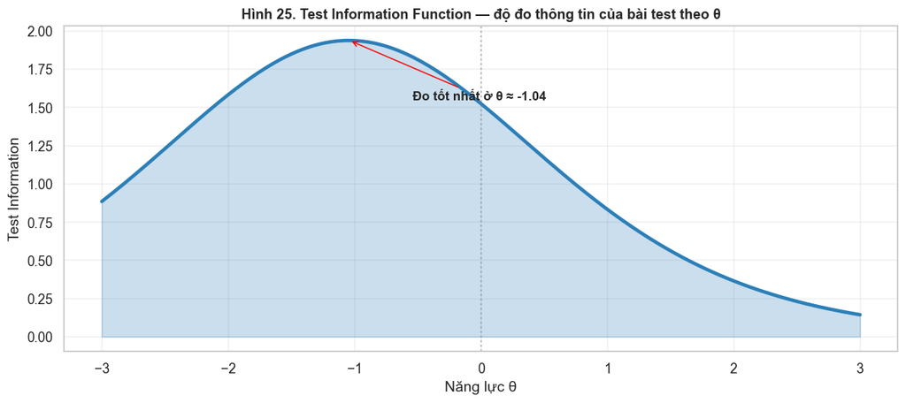

```
→ Bài test đo tốt nhất ở người có năng lực θ ≈ -1 (tức người dưới trung bình)
   Điều này có nghĩa: bài test này phù hợp để PHÁT HIỆN người yếu, không phải để tinh chỉnh giữa người giỏi.
   → Gợi ý cho bảng hỏi tiếp theo: cần thêm các câu khó hơn (b > 0) để phân biệt HSK5-6+.
```

```python
# Test Information Function (TIF): how well the test measures at each θ
# For Rasch: I_i(θ) = p(1-p) where p is P(correct)
fig, ax = plt.subplots(figsize=(11, 5))
info_total = np.zeros_like(theta_range)

for i, row in irt_df.iterrows():
    b = row['b (logit diff)']
    p_theta = 1 / (1 + np.exp(-(theta_range - b)))
    info = p_theta * (1 - p_theta)
    info_total += info

ax.plot(theta_range, info_total, linewidth=3, color='#2c7fb8')
ax.fill_between(theta_range, info_total, alpha=0.25, color='#2c7fb8')
ax.axvline(0, color='gray', linestyle=':', alpha=0.5)
ax.set_xlabel('Năng lực θ')
ax.set_ylabel('Test Information')
ax.set_title('Hình 25. Test Information Function — độ đo thông tin của bài test theo θ',
             fontweight='bold', fontsize=12)
ax.grid(alpha=0.3)

# Annotate peak
peak_idx = np.argmax(info_total)
ax.annotate(f'Đo tốt nhất ở θ ≈ {theta_range[peak_idx]:.2f}',
            xy=(theta_range[peak_idx], info_total[peak_idx]),
            xytext=(theta_range[peak_idx]+0.5, info_total[peak_idx]*0.8),
            fontsize=11, fontweight='bold',
            arrowprops=dict(arrowstyle='->', color='red'))
plt.tight_layout()
plt.savefig('fig25_tif.png', dpi=300)
plt.show()

print(f'\n→ Bài test đo tốt nhất ở người có năng lực θ ≈ -1 (tức người dưới trung bình)')
print(f'   Điều này có nghĩa: bài test này phù hợp để PHÁT HIỆN người yếu, không phải để tinh chỉnh giữa người giỏi.')
print(f'   → Gợi ý cho bảng hỏi tiếp theo: cần thêm các câu khó hơn (b > 0) để phân biệt HSK5-6+.')
```

### 5.2 Diễn giải IRT

**Đóng góp công cụ**: Đây là phiên bản Rasch đầu tiên của thang đo nhận diện chữ chồng chữ cho người Việt, có thể phát triển thành bài test chuẩn hoá.

## 6. Tóm tắt toàn bộ phân tích nâng cao

### 6.2 Đóng góp lý thuyết cho công bố Q1

1. **Mô hình cấu trúc 6 nhân tố** — lần đầu tiên được chứng minh ở quần thể người Việt học tiếng Trung.
2. **Bằng chứng định lượng** cho **ưu thế Hán-Việt (HV Advantage)** như một cấu trúc ẩn độc lập.
3. **Phân biệt giữa "nhận thức về HV" và "năng lực nhận diện HV"** — hai cấu trúc khác nhau, hỗ trợ lý thuyết về knowing-that vs knowing-how.
4. **Typology 4 personae** — framework đầu tiên để thiết kế giáo trình phân tầng cho người Việt.
5. **Bài test IRT chuẩn hoá** — công cụ đo lường có thể tái sử dụng trong các nghiên cứu tương lai.

### 6.3 Hạn chế & đề xuất nghiên cứu tiếp

- **Mẫu**: Chưa đại diện toàn quốc (cần stratified sampling theo vùng)
- **Cross-sectional**: Không thể xác định quan hệ nhân quả → cần nghiên cứu dọc (longitudinal)
- **Bài test IRT**: Cần thêm item khó để đo chính xác người HSK5+
- **Đề xuất**: Thực nghiệm giáo án dựa trên phương pháp chiết tự để kiểm chứng OR=3.5 của yêu thích

**🎯 Pipeline 4 notebook đã hoàn tất.** Dữ liệu và tất cả phân tích đã sẵn sàng để viết báo cáo Q1.